# DATA VISUALIZATION PROJECT

> BY: RITIKA MANDAL

## CONTENTS:

> DATA GATHERING

> UNIVARIATE ANALYSIS

> BIVARIATE ANALYSIS

> MULTIVARIATE ANALYSIS

### WHAT IS THE STRUCTURE OF DATASET ?

> The dataset has 113937 entries, with information regarding various loans issues in the bank.

> It has 81 different columns giving information about various things such as Term, BorrowRate,Lenderyield etc.

### WHAT IS THE AREA OF INTEREST ?

> I'm interested in complete investigation of the dataset as come up with necessary visualizations and results.

```python
import pandas as pd
import matplotlib.pyplot as plt
import numpy as np
import seaborn as sns
```

```python
df = pd.read_csv("C:/Users/RITIKA MANDAL/Downloads/nanodegree/prosperLoanData.csv")
```

```python
df.head()
```

|  | ListingKey | ListingNumber | ListingCreationDate | CreditGrade | Term | LoanStatus | ClosedDate | BorrowerAPR | BorrowerRate | LenderYield | ... | LP_ServiceFees | LP_CollectionFees | LP_GrossPrincipalLoss | LP_NetPrincipalLoss | LP_NonPrincipalRecoverypayments | PercentFunded | Recommendations | InvestmentFromFriendsCount | InvestmentFromFriendsAmount | Investors |
| --- | --- | --- | --- | --- | --- | --- | --- | --- | --- | --- | --- | --- | --- | --- | --- | --- | --- | --- | --- | --- | --- |
| 0 | 1021339766868145413AB3B | 193129 | 2007-08-26 19:09:29.263000000 | C | 36 | Completed | 2009-08-14 00:00:00 | 0.16516 | 0.1580 | 0.1380 | ... | -133.18 | 0.0 | 0.0 | 0.0 | 0.0 | 1.0 | 0 | 0 | 0.0 | 258 |
| 1 | 10273602499503308B223C1 | 1209647 | 2014-02-27 08:28:07.900000000 | NaN | 36 | Current | NaN | 0.12016 | 0.0920 | 0.0820 | ... | 0.00 | 0.0 | 0.0 | 0.0 | 0.0 | 1.0 | 0 | 0 | 0.0 | 1 |
| 2 | 0EE9337825851032864889A | 81716 | 2007-01-05 15:00:47.090000000 | HR | 36 | Completed | 2009-12-17 00:00:00 | 0.28269 | 0.2750 | 0.2400 | ... | -24.20 | 0.0 | 0.0 | 0.0 | 0.0 | 1.0 | 0 | 0 | 0.0 | 41 |
| 3 | 0EF5356002482715299901A | 658116 | 2012-10-22 11:02:35.010000000 | NaN | 36 | Current | NaN | 0.12528 | 0.0974 | 0.0874 | ... | -108.01 | 0.0 | 0.0 | 0.0 | 0.0 | 1.0 | 0 | 0 | 0.0 | 158 |
| 4 | 0F023589499656230C5E3E2 | 909464 | 2013-09-14 18:38:39.097000000 | NaN | 36 | Current | NaN | 0.24614 | 0.2085 | 0.1985 | ... | -60.27 | 0.0 | 0.0 | 0.0 | 0.0 | 1.0 | 0 | 0 | 0.0 | 20 |

5 rows × 81 columns

```python
df.info()
```

```
<class 'pandas.core.frame.DataFrame'>
RangeIndex: 113937 entries, 0 to 113936
Data columns (total 81 columns):
 #   Column                               Non-Null Count   Dtype
---  ------                               --------------   -----
 0   ListingKey                           113937 non-null  object
 1   ListingNumber                        113937 non-null  int64
 2   ListingCreationDate                  113937 non-null  object
 3   CreditGrade                          28953 non-null   object
 4   Term                                 113937 non-null  int64
 5   LoanStatus                           113937 non-null  object
 6   ClosedDate                           55089 non-null   object
 7   BorrowerAPR                          113912 non-null  float64
 8   BorrowerRate                         113937 non-null  float64
 9   LenderYield                          113937 non-null  float64
```

[output cut: 73 more lines]

```python
df.describe()
```

|  | ListingNumber | Term | BorrowerAPR | BorrowerRate | LenderYield | EstimatedEffectiveYield | EstimatedLoss | EstimatedReturn | ProsperRating (numeric) | ProsperScore | ... | LP_ServiceFees | LP_CollectionFees | LP_GrossPrincipalLoss | LP_NetPrincipalLoss | LP_NonPrincipalRecoverypayments | PercentFunded | Recommendations | InvestmentFromFriendsCount | InvestmentFromFriendsAmount | Investors |
| --- | --- | --- | --- | --- | --- | --- | --- | --- | --- | --- | --- | --- | --- | --- | --- | --- | --- | --- | --- | --- | --- |
| count | 1.139370e+05 | 113937.000000 | 113912.000000 | 113937.000000 | 113937.000000 | 84853.000000 | 84853.000000 | 84853.000000 | 84853.000000 | 84853.000000 | ... | 113937.000000 | 113937.000000 | 113937.000000 | 113937.000000 | 113937.000000 | 113937.000000 | 113937.000000 | 113937.000000 | 113937.000000 | 113937.000000 |
| mean | 6.278857e+05 | 40.830248 | 0.218828 | 0.192764 | 0.182701 | 0.168661 | 0.080306 | 0.096068 | 4.072243 | 5.950067 | ... | -54.725641 | -14.242698 | 700.446342 | 681.420499 | 25.142686 | 0.998584 | 0.048027 | 0.023460 | 16.550751 | 80.475228 |
| std | 3.280762e+05 | 10.436212 | 0.080364 | 0.074818 | 0.074516 | 0.068467 | 0.046764 | 0.030403 | 1.673227 | 2.376501 | ... | 60.675425 | 109.232758 | 2388.513831 | 2357.167068 | 275.657937 | 0.017919 | 0.332353 | 0.232412 | 294.545422 | 103.239020 |
| min | 4.000000e+00 | 12.000000 | 0.006530 | 0.000000 | -0.010000 | -0.182700 | 0.004900 | -0.182700 | 1.000000 | 1.000000 | ... | -664.870000 | -9274.750000 | -94.200000 | -954.550000 | 0.000000 | 0.700000 | 0.000000 | 0.000000 | 0.000000 | 1.000000 |
| 25% | 4.009190e+05 | 36.000000 | 0.156290 | 0.134000 | 0.124200 | 0.115670 | 0.042400 | 0.074080 | 3.000000 | 4.000000 | ... | -73.180000 | 0.000000 | 0.000000 | 0.000000 | 0.000000 | 1.000000 | 0.000000 | 0.000000 | 0.000000 | 2.000000 |
| 50% | 6.005540e+05 | 36.000000 | 0.209760 | 0.184000 | 0.173000 | 0.161500 | 0.072400 | 0.091700 | 4.000000 | 6.000000 | ... | -34.440000 | 0.000000 | 0.000000 | 0.000000 | 0.000000 | 1.000000 | 0.000000 | 0.000000 | 0.000000 | 44.000000 |
| 75% | 8.926340e+05 | 36.000000 | 0.283810 | 0.250000 | 0.240000 | 0.224300 | 0.112000 | 0.116600 | 5.000000 | 8.000000 | ... | -13.920000 | 0.000000 | 0.000000 | 0.000000 | 0.000000 | 1.000000 | 0.000000 | 0.000000 | 0.000000 | 115.000000 |
| max | 1.255725e+06 | 60.000000 | 0.512290 | 0.497500 | 0.492500 | 0.319900 | 0.366000 | 0.283700 | 7.000000 | 11.000000 | ... | 32.060000 | 0.000000 | 25000.000000 | 25000.000000 | 21117.900000 | 1.012500 | 39.000000 | 33.000000 | 25000.000000 | 1189.000000 |

8 rows × 61 columns

```python
df['ListingCreationDate'] = df['ListingCreationDate'].astype('datetime64[ns]')
df['ClosedDate'] = df['ClosedDate'].astype('datetime64[ns]')
```

## UNIVARIATE EXPLORATION

**The code snippet below demonstrates the use of function for code length reduction**

```python
# Use of a function

def countplot( a , b):
    sns.countplot(data = a, x = b,color=b_col)
```

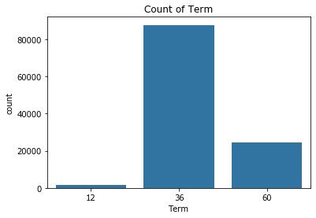

```python
b_col = sns.color_palette()[0]
countplot(df,'Term')  # Calling the function countplot.
plt.title('Count of Term')
```

### WHAT IS THE TERM RATE IN WHICH PEOPLE ARE MOST INTERESTED IN INVESTING ?

> From the above bar graph we can see that, there are maximum number of people who issue a loan for a period of 36 months, followed by a period of 60 months and then 12 months.

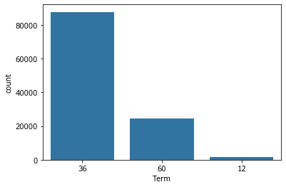

```python
b_col = sns.color_palette()[0]
cat_order = df.Term.value_counts().index
sns.countplot(data = df, x = 'Term',color=b_col,order= cat_order)
```

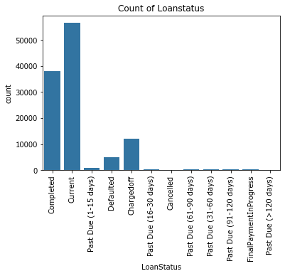

```python
b_col = sns.color_palette()[0]
countplot(df,'LoanStatus')
plt.xticks(rotation=90)
plt.title('Count of Loanstatus')
```

#### WHAT IS THE OBSERVATION FROM THE ABOVE GRAPH ?

> On examining the loan Status, we can see that, current loan status is the maximum followed by the completed loan status.

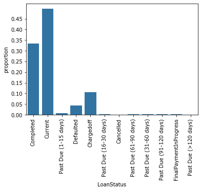

```python
n_p = df.shape[0]
max_cnt = df['LoanStatus'].value_counts().max()
max_prop = max_cnt / n_p
tick_props = np.arange(0, max_prop, 0.05)
tick_names = ['{:0.2f}'.format(v) for v in tick_props]
base_color = sns.color_palette()[0]
sns.countplot(data = df, x = 'LoanStatus', color = base_color)
plt.yticks(tick_props * n_p, tick_names)
plt.ylabel('proportion')
plt.xticks(rotation=90);
```

#### Next, I have plotted the bar graph of the number of people belonging to different grade count.

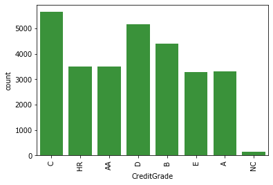

```python
b_col = sns.color_palette()[2]
countplot(df,'CreditGrade')
plt.xticks(rotation=90)
```

#### WHICH CREDIT GRADE COMPRISES OF THE MAXIMUM NUMBER OF LOAN ISSUERS?

> iT IS CLEARLY SEEN THAT GRADE C HAS THE LARGEST NUMBER OF PEOPLE ISSUING LOANS

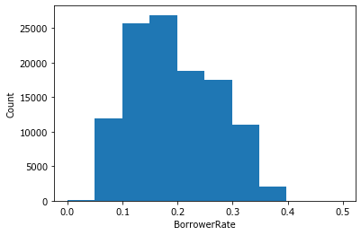

```python
bin_edges = np.arange(0, df['BorrowerRate'].max()+1, 1)
plt.hist(data = df, x = 'BorrowerRate')
plt.xlabel('BorrowerRate')
plt.ylabel('Count')
```

#### WHAT IS INTERPRETED FROM THE GRAPHS ABOVE AND BELOW?

> It shows the distribution of BorrowRate

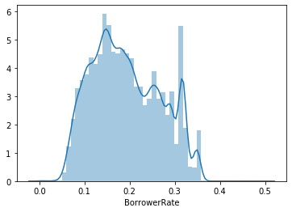

```python
sns.distplot(df['BorrowerRate'])
```

## BIVARIATE EXPLORATION

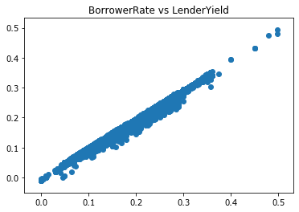

```python
plt.scatter(data = df, x = 'BorrowerRate', y = 'LenderYield')
plt.title('BorrowerRate vs LenderYield')
```

**USE OF FUNCTION TO CREATE REGPLOT**

```python
def rplt(a , b, c):
    sns.regplot(data = a, x = b, y = c, scatter_kws = {'alpha':1/10})
```

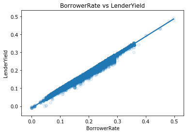

```python
rplt(df,'BorrowerRate','LenderYield') # CALLING FUNCTION RPLT.
plt.title('BorrowerRate vs LenderYield')
```

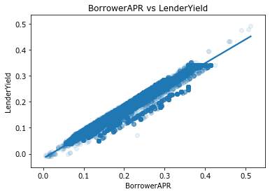

```python
rplt(df,'BorrowerAPR','LenderYield')
plt.title('BorrowerAPR vs LenderYield');
```

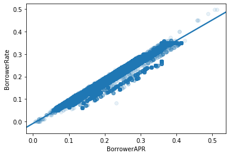

```python
sns.regplot(data = df, x = 'BorrowerAPR', y = 'BorrowerRate', scatter_kws = {'alpha' : 1/10})
```

#### WHAT IS THE RELATIONSHIP BETWEEN LOANSTATUS AND LENDERYIELD?

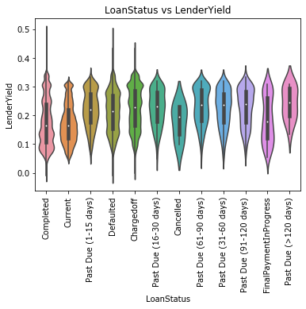

```python
sns.violinplot(data = df, x = 'LoanStatus', y = 'LenderYield')
plt.xticks(rotation=90)
plt.title('LoanStatus vs LenderYield')
```

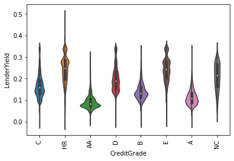

```python
sns.violinplot(data = df, x = 'CreditGrade', y = 'LenderYield')
plt.xticks(rotation=90)
```

**The above plot represents the relationship between CreditGrade and LenderYield. The shapes where the edges are extremely skinny and thick at the centre represents that LenderYield is concentrated around the median.**

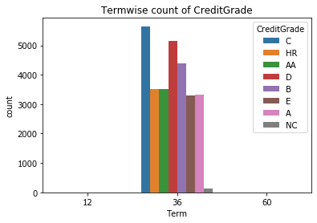

```python
sns.countplot(data = df, x = 'Term', hue = 'CreditGrade')
plt.title('Termwise count of CreditGrade')
```

**The plot above represents the Termwise count of CreditGrade. We can see that almost everyone issue a laon for a period of 36 months. And the maximum number of people issueing loans belong to Grade C followed by Grade D.**

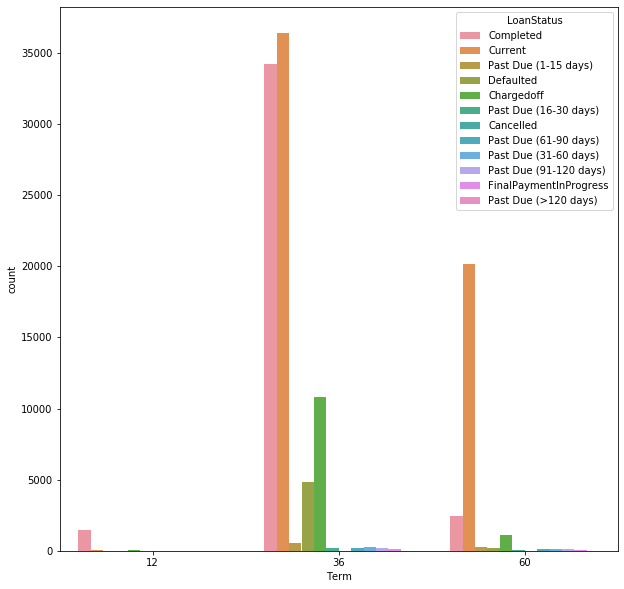

```python
plt.figure(figsize=(10,10))
sns.countplot(data = df, x = 'Term', hue = 'LoanStatus')
```

**The above graph shows the relationship between Term and LoanStatus**

### RELATIONSHIP BETWEEN CREDIT GRADE AND LOAN STATUS

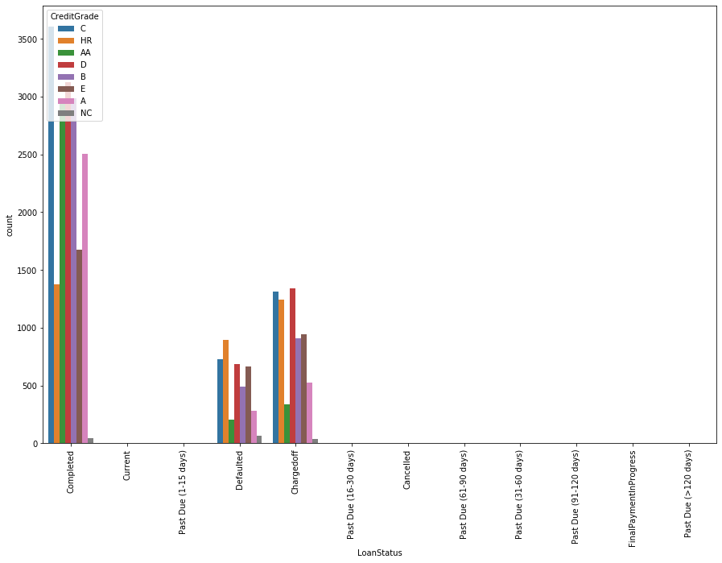

```python
plt.figure(figsize=(15,10))
sns.countplot(data = df, x = 'LoanStatus', hue = 'CreditGrade')
plt.xticks(rotation=90)
```

```python
df.IncomeRange.value_counts()
```

```
$25,000-49,999    32192
$50,000-74,999    31050
$100,000+         17337
$75,000-99,999    16916
Not displayed      7741
$1-24,999          7274
Not employed        806
$0                  621
Name: IncomeRange, dtype: int64
```

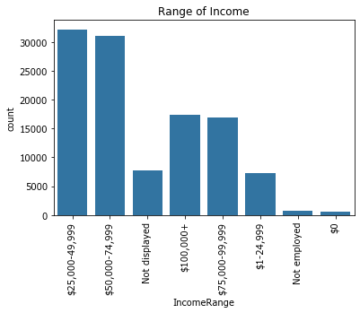

```python
b_col = sns.color_palette()[0]
sns.countplot(data = df, x = 'IncomeRange',color=b_col)
plt.title('Range of Income')
plt.xticks(rotation=90)
```

```python
df.Occupation.value_counts()
```

```
Other                          28617
Professional                   13628
Computer Programmer             4478
Executive                       4311
Teacher                         3759
                               ...
Dentist                           68
Student - College Freshman        41
Student - Community College       28
Judge                             22
Student - Technical School        16
Name: Occupation, Length: 67, dtype: int64
```

#### RELATIONSHIP BETWEEN OCCUPATION AND INCOME RANGE:

> HOW IS OCCUPATION RELATED TO INCOME?

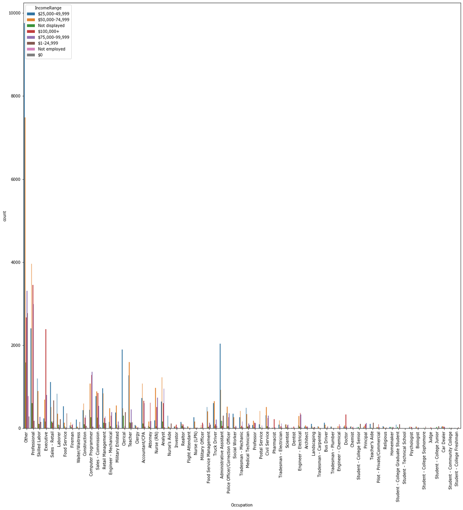

```python
plt.figure(figsize=(20,20))
sns.countplot(data = df, x = 'Occupation', hue = 'IncomeRange')
plt.xticks(rotation=90)
```

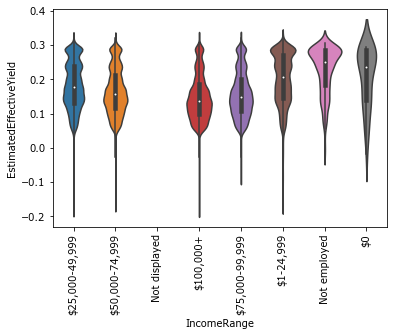

```python
sns.violinplot(data = df, x = 'IncomeRange', y = 'EstimatedEffectiveYield')
plt.xticks(rotation=90)
```

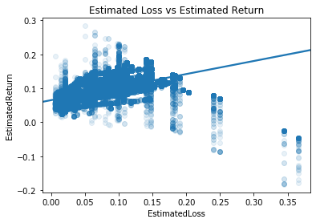

```python
sns.regplot(data = df, x = 'EstimatedLoss', y = 'EstimatedReturn', scatter_kws = {'alpha' : 1/10})
plt.title('Estimated Loss vs Estimated Return')
```

## MULTIVARIATE EXPLORATION

### WHAT IS RELATION BETWEEN BORROW RATE AND ESTIMATED RETURN BASED ON INCOME?

> THE GRAPH BELOW CLEARLY SHOWS THE ABOVE RELATIONSHIP AND THE MINUTE DETAILS ASSOCIATED WITH IT

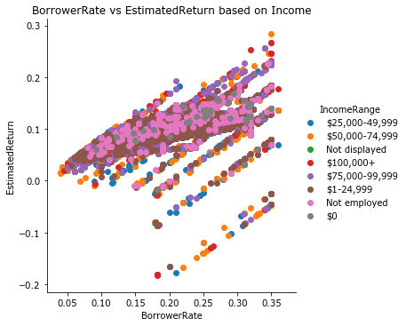

```python
g = sns.FacetGrid(data = df, hue = 'IncomeRange', size = 5)
g.map(plt.scatter,  'BorrowerRate','EstimatedReturn')
g.add_legend()
plt.title('BorrowerRate vs EstimatedReturn based on Income')
```

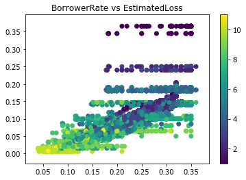

```python
plt.scatter(data = df, x = 'BorrowerRate', y = 'EstimatedLoss', c = 'ProsperScore')
plt.colorbar()
plt.title('BorrowerRate vs EstimatedLoss')
```

#### In the above multivariate exploration graphs, we can see the distribution of BorrowerRate vs. EstimatedReturn based on income.

#### We can also see the relationship between BorrowerRate and EstimatedLoss based on ProsperScore

### SUMMARY AND CONCLUSION

The loan dataset has a large number columns from which the following conclusions can be drawn:

> The loan can be issued for a period of 36,12 or 60 months. The people issuing loan for a period of 36 months is the greatest followed by 60 months and 12 months.

> In the loan status column, the people with "current" loan status are the maximum followed by "completed".

> Violin plots of LoanStatus vs LenderYield gives us a clear picture.

> Similarly, term vs loanstatus was also plotted.

> From the Loan dataset we can find that maximum people issuing loans have an income range between 25,000-49,999 $